# Naive Bayes

Jared Salinas

21/1/2019

### Leyendo la información

```r
sms_raw<-read.csv("data/sms_spam.csv",stringsAsFactors = FALSE)
```

Vemos información del dataset

```r
str(sms_raw)
```

```
## 'data.frame':    5574 obs. of  2 variables:
##  $ type: chr  "ham" "ham" "spam" "ham" ...
##  $ text: chr  "Go until jurong point, crazy.. Available only in bugis n great world la e buffet... Cine there got amore wat..." "Ok lar... Joking wif u oni..." "Free entry in 2 a wkly comp to win FA Cup final tkts 21st May 2005. Text FA to 87121 to receive entry question("| __truncated__ "U dun s…
```

La información son el texto, y una clasificación (spam o ham)

## Vemos información estadistica del caso de estudio

```r
summary(sms_raw)
```

```
##      type               text
##  Length:5574        Length:5574
##  Class :character   Class :character
##  Mode  :character   Mode  :character
```

Número de spam y ham

```r
table(sms_raw$type)
```

```
##
##  ham spam
## 4827  747
```

Hay más información sobre ham que de spam

## Procesamiento de los datos

Como es un conjunto de texto, tenemos que hacer una limpieza de los datos, quitar información irrelevante para el clasificador, tener en cuenta que es importante saber que los mensajes que contienen spam, te regalan algo, o te dan algo muy dificil de obtener. Es por eso que usan mucho la palabra “free”

```r
#importamos librería necesaria
library(tm)
sms_corpus<-VCorpus(VectorSource(sms_raw$text))

print(sms_corpus)
```

```
## <<VCorpus>>
## Metadata:  corpus specific: 0, document level (indexed): 0
## Content:  documents: 5574
```

Hacemos elementos de tipo documentos.

visualizamos los datos de los documentos.

```r
# visualizar los datos del corpus
inspect(sms_corpus[1:2])
```

```
## <<VCorpus>>
## Metadata:  corpus specific: 0, document level (indexed): 0
## Content:  documents: 2
##
## [[1]]
## <<PlainTextDocument>>
## Metadata:  7
## Content:  chars: 111
##
## [[2]]
## <<PlainTextDocument>>
## Metadata:  7
## Content:  chars: 29
```

```r
as.character(sms_corpus[[1]])
```

```
## [1] "Go until jurong point, crazy.. Available only in bugis n great world la e buffet... Cine there got amore wat..."
```

La función lappy nos deja poder más de dos documentos, ya que afecta al conjunto

```r
lapply(sms_corpus[1:2], as.character)
```

```
## $`1`
## [1] "Go until jurong point, crazy.. Available only in bugis n great world la e buffet... Cine there got amore wat..."
##
## $`2`
## [1] "Ok lar... Joking wif u oni..."
```

Primero tenemos que hacer que nuestras cadenas de texto esten todas en minusculas

```r
sms_corpus_clean<-tm_map(sms_corpus, content_transformer(tolower))

as.character(sms_corpus[[1]])
```

```
## [1] "Go until jurong point, crazy.. Available only in bugis n great world la e buffet... Cine there got amore wat..."
```

```r
as.character(sms_corpus_clean[[1]])
```

```
## [1] "go until jurong point, crazy.. available only in bugis n great world la e buffet... cine there got amore wat..."
```

Removemos Números de nuestros textos

```r
sms_corpus_clean<-tm_map(sms_corpus_clean,removeNumbers)
```

También información irrelevante, en nuestro caso, son los nexos, uniones. Para eso usamos la función stopwords y tambien puntuaciones con con removePunctuation

```r
sms_corpus_clean<-tm_map(sms_corpus_clean,removeWords,stopwords())
sms_corpus_clean<-tm_map(sms_corpus_clean,removePunctuation)
as.character(sms_corpus_clean[[1]])
```

```
## [1] "go  jurong point crazy available   bugis n great world la e buffet cine  got amore wat"
```

```r
library(SnowballC)
```

WordStem nos saca la radical de las palabras

```r
wordStem(c("learn", "learned", "learning","learns"))
```

```
## [1] "learn" "learn" "learn" "learn"
```

```r
wordStem(c("videogamer","gamer","gaming","gamer"))
```

```
## [1] "videogam" "gamer"    "game"     "gamer"
```

```r
sms_corpus_clean<-tm_map(sms_corpus_clean, stemDocument)
as.character(sms_corpus_clean[[1]])
```

```
## [1] "go jurong point crazi avail bugi n great world la e buffet cine got amor wat"
```

Removemos espacios vacios

```r
sms_corpus_clean<-tm_map(sms_corpus_clean, stripWhitespace)

#print(as.character(sms_corpus[1:3]))
#as.character(sms_corpus[1:3])
print(as.character(sms_corpus_clean[1:3]))
```

```
## [1] "list(list(content = \"go jurong point crazi avail bugi n great world la e buffet cine got amor wat\", meta = list(author = character(0), datetimestamp = list(sec = 21.6984379291534, min = 48, hour = 6, mday = 22, mon = 0, year = 119, wday = 2, yday = 21, isdst = 0), description = character(0…
## [2] "list()"
## [3] "list()"
```

```r
as.character(sms_corpus_clean[1])
```

```
## [1] "list(list(content = \"go jurong point crazi avail bugi n great world la e buffet cine got amor wat\", meta = list(author = character(0), datetimestamp = list(sec = 21.6984379291534, min = 48, hour = 6, mday = 22, mon = 0, year = 119, wday = 2, yday = 21, isdst = 0), description = character(0…
## [2] "list()"
## [3] "list()"
```

## Preparación de los datos

```r
sms_dtm<-DocumentTermMatrix(sms_corpus_clean)
```

Pudimos haber hecho todo lo anterior con la siguiente linea:

```r
sms_dtm2<-DocumentTermMatrix(sms_corpus,
                             control = list(tolower=TRUE,
                                            removeNumbers=TRUE,
                                            stopwords=TRUE,
                                            removePunctuation=TRUE,
                                            stemming=TRUE))
```

```r
sms_dtm
```

```
## <<DocumentTermMatrix (documents: 5574, terms: 6592)>>
## Non-/sparse entries: 42608/36701200
## Sparsity           : 100%
## Maximal term length: 40
## Weighting          : term frequency (tf)
```

```r
sms_dtm2
```

```
## <<DocumentTermMatrix (documents: 5574, terms: 6995)>>
## Non-/sparse entries: 43713/38946417
## Sparsity           : 100%
## Maximal term length: 40
## Weighting          : term frequency (tf)
```

```r
sms_dtm_train<-sms_dtm[1:4169,]
sms_dtm_test<-sms_dtm[4170:5559,]

sms_train_labels<-sms_raw[1:4169,]$type
sms_test_labels<-sms_raw[4170:5559,]$type

prop.table(table(sms_train_labels))
```

```
## sms_train_labels
##       ham      spam
## 0.8647158 0.1352842
```

```r
prop.table(table(sms_test_labels))
```

```
## sms_test_labels
##       ham      spam
## 0.8697842 0.1302158
```

Hacemos los cortes de prueba y entrenamiento y vemos la distribución del ham y el spam

## Visualizando la información

Además hacemos una nube de palabras para identificar las palabras más sonadas en el documento.

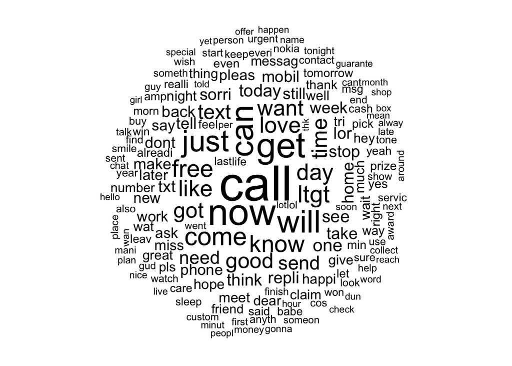

```r
library(wordcloud)
wordcloud(sms_corpus_clean,min.freq = 50, random.order = FALSE)
```

```r
options(warnings=2)
```

Vemos otras nubes de palabras unas del spam y otra del ham

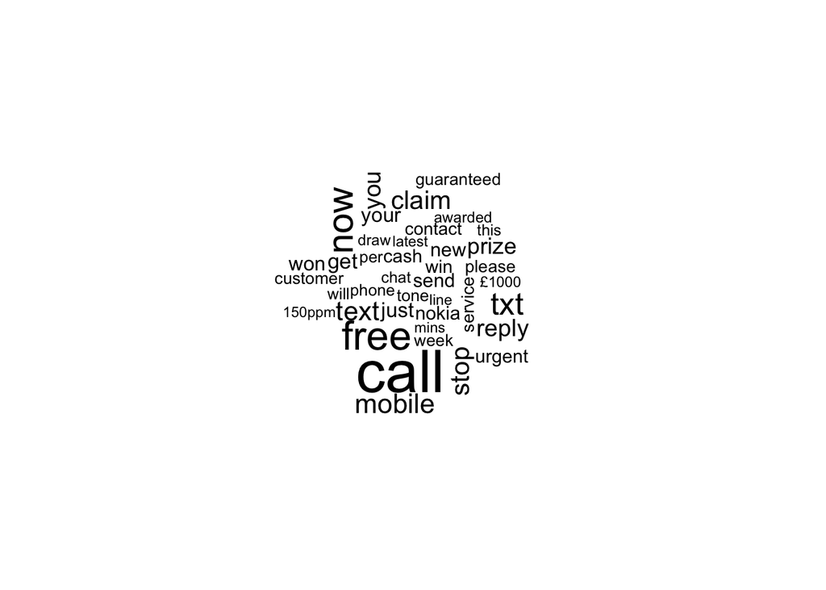

```r
spam<-subset(sms_raw,type=="spam")
ham<-subset(sms_raw,type=="ham")

wordcloud(spam$text,max.words = 40,scale=c(3,0.5))
```

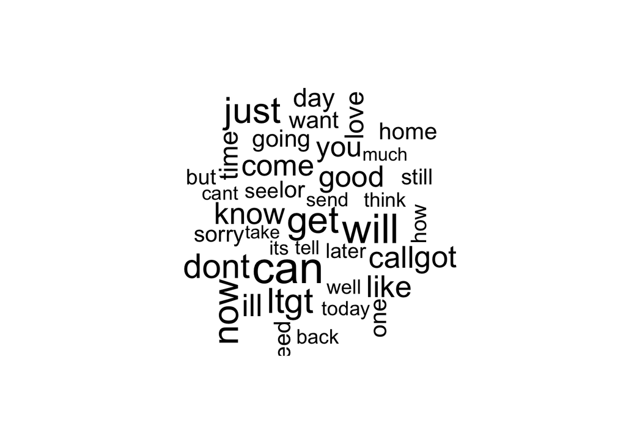

```r
wordcloud(ham$text,max.words = 40, scale=c(3,0.5))
```

Vamos hacer más limpio la prueba, haciendo que solo busque la que tenga más de 5 menciones

```r
findFreqTerms(sms_dtm_train,5)
```

```
##    [1] "£wk"           "abiola"        "abl"           "abt"
##    [5] "accept"        "access"        "account"       "across"
##    [9] "activ"         "actual"        "add"           "address"
##   [13] "admir"         "adult"         "advanc"        "aft"
##   [17] "afternoon"     "aftr"          "age"           "ago"
##   [21] "ahead"         "aight"         "aint"          "air"
##   [25] "aiyah"         "alex"          "almost"        "alon"
##   [29] "alreadi"       "alright"       "alrit"         "also"
##   [33] "alway"         "amp"           "angri"         "announc"
##   [37] "anoth"         "answer"        "anybodi"       "anymor"
##   [41] "anyon"         "anyth"         "anytim"        "anyway"
##   [45] "apart"         "app"           "appli"         "appoint"
##   [49] "appreci"       "april"         "ard"           "area"
##   [53] "argument"      "arm"           "around"        "arrang"
##   [57] "arrest"        "arriv"         "asap"          "ask"
```

[output cut: 275 more lines]

```r
sms_freq_words<-findFreqTerms(sms_dtm_train,5)

str(sms_freq_words)
```

```
##  chr [1:1157] "£wk" "abiola" "abl" "abt" "accept" "access" "account" ...
```

```r
sms_dtm_freq_train<- sms_dtm_train[ , sms_freq_words]
sms_dtm_freq_test <- sms_dtm_test[ , sms_freq_words]


##hacer una funcion que nos diga si es spam o no

convert_counts <- function(x) {
    x <- ifelse(x > 0, "Yes", "No")
}


sms_train <- apply(sms_dtm_freq_train, MARGIN = 2,
                                       convert_counts)
sms_test <- apply(sms_dtm_freq_test, MARGIN = 2,
                                      convert_counts)

str(sms_train)
```

```
##  chr [1:4169, 1:1157] "No" "No" "No" "No" "No" "No" "No" "No" "No" ...
##  - attr(*, "dimnames")=List of 2
##   ..$ Docs : chr [1:4169] "1" "2" "3" "4" ...
##   ..$ Terms: chr [1:1157] "£wk" "abiola" "abl" "abt" ...
```

```r
str(sms_test)
```

```
##  chr [1:1390, 1:1157] "No" "No" "No" "No" "No" "No" "No" "No" "No" ...
##  - attr(*, "dimnames")=List of 2
##   ..$ Docs : chr [1:1390] "4170" "4171" "4172" "4173" ...
##   ..$ Terms: chr [1:1157] "£wk" "abiola" "abl" "abt" ...
```

```r
install.packages("e1071",repos = "http://cran.us.r-project.org")
```

[output not shown]

```
## installing the source package 'e1071'
```

```r
library(e1071)
```

```r
sms_classifier <- naiveBayes(sms_train, sms_train_labels)

#making predictions
sms_test_pred <- predict(sms_classifier, sms_test)

head(sms_test_pred)
```

```
## factor(0)
## Levels:
```

```r
#install.packages("gmodels", repos = "http://cran.us.r-project.org")
#library(gmodels)

length(sms_test_pred)
```

```
## [1] 0
```

```r
#CrossTable(sms_test_pred, sms_test_labels,
 #   prop.chisq = FALSE, prop.t = FALSE,
  #  dnn = c('predicted', 'actual'))

#table(sms_test_pred,sms_test_labels)
```

```r
sms_classifier2<-naiveBayes(sms_train,sms_train_labels,laplace = 1)
sms_tes_pred2<-predict(sms_classifier2,sms_test)

#CrossTable(sms_tes_pred2,sms_test_labels,prop.chisq = FALSE, prop.t = FALSE,
         #  dnn = c("predicted","actual"))

#table(sms_tes_pred2,sms_test_labels)
```